# R Notebook

# Statistics XI Homework Ch17,18_Textbook

## 17.03

### 1

Multicollinearity

```r
#data processing
data1 <- read.csv("Xr17-03.csv",header = 1)
drywall <- data1$Drywall
permits <- data1$Permits
mortgage <- data1$Mortgage
a_vacancy <- data1$A.Vacancy
o_vacancy <- data1$O.Vacancy
Data.Drywall <- cbind(permits,mortgage,a_vacancy,o_vacancy)
#
cor(Data.Drywall)
```

```
               permits     mortgage   a_vacancy   o_vacancy
permits    1.000000000  0.004653691 -0.15045538 -0.10269494
mortgage   0.004653691  1.000000000 -0.03985549 -0.03321291
a_vacancy -0.150455377 -0.039855489  1.00000000  0.06518328
o_vacancy -0.102694942 -0.033212912  0.06518328  1.00000000
```

Since each of |r| between the independent variables < 0.7, we can infer that multicollinearity is not a problem.

### 2

Autocorrelation

We use Durbin-Watson Statistic to detect auto-correlation between consecutive residuals in a time series.

```
2-tail test for first order auto-correlation:
```

$$H_0:\ The\ data\ are\ not\ first-order\ correlated.\\
H_1:\ The\ data\ are\ first-order\ correlated.$$

```r
standarized_errors_MR <- function(y, x) {
   n <- length(y)
   k <- ncol(x)
   x1 <- vector("double", length = n)
   for(j in 1:n) {
      x1[j] <- 1
      }
   Matrix_X <- cbind(x1, x)
   Matrix_Y <- cbind(y)
   Matrix_H <-  Matrix_X%*%solve(t(Matrix_X)%*%Matrix_X)%*%t(Matrix_X)
   Matrix_YP <-  Matrix_H%*%Matrix_Y
   y_p <- Matrix_YP[,1]
   h <- vector("double", length = n)
   D <- vector("double", length = n)
      Error <- vector("double", length = n)
   Standard_E <- vector("double", length = n)
   se <- sqrt(sum((y - y_p)^2)/(n - k - 1))
   for(i in 1:n) {
      h[i] <- Matrix_H[i,i]
      Error[i] <- y[i] - y_p[i]
      Standard_E[i] <- Error[i] / (se * sqrt(1 - h[i]))
      D[i] <- (y[i] - y_p[i])^2 * h[i] / ((k -1) * se^2 * (1 - h[i])^2)
      }
   SEhD <- cbind(Standard_E, h, D)
   return(SEhD)
}
```

```r
SE <- standarized_errors_MR(drywall, Data.Drywall)[ ,1]
Durbin_Watson_Test <- function(x) {
   x_square_sum <- sum(x*x)
   n <- length(x)
   x_d <- vector("double", length = n)
   x_d[1] = 0
   for(j in 2:n) {
      x_d[j] <- x[j] - x[j - 1]
      }
   d <- sum(x_d*x_d) / x_square_sum
    return(d)
}
cat("# # # # The Durbin Watson Test # # # ","\n")
```

```
# # # # The Durbin Watson Test # # #
```

```r
DW_test <- Durbin_Watson_Test(SE)
print(DW_test)
```

```
[1] 1.774199
```

```r
n <- length(drywall)
k <- ncol(Data.Drywall)
cat("k = ",k,", n =  ",n)
```

```
k =  4 , n =   24
```

From the table of Durbin-Watson Statistic(k = 4, n = 24), we find $d_L$ = 1.01 and $d_U$ = 1.78. Since $d_L < $d = 1.774199 < $d_U$ , the test is inconclusive.

## 17.07

### 1

Multicollinearity

```r
#data processing
data2 <- read.csv("Xr17-07.csv",header = 1)
sales <- data2$Sales
direct <- data2$Direct
newspaper <- data2$Newspaper
TV <- data2$Television
Data.Sales <- cbind(direct,newspaper,TV)
#
cor(Data.Sales)
```

```
              direct  newspaper         TV
direct     1.0000000 -0.1376348 -0.1246090
newspaper -0.1376348  1.0000000  0.1467502
TV        -0.1246090  0.1467502  1.0000000
```

Since each of |r| between the independent variables < 0.7, we can infer that multicollinearity is not a problem.

### 2

Autocorrelation We use Durbin-Watson Statistic to detect auto-correlation between consecutive residuals in a time series.

```
2-tail test for first order auto-correlation:
```

$$H_0:\ The\ data\ are\ not\ first-order\ correlated.\\
H_1:\ The\ data\ are\ first-order\ correlated.$$

```r
SE <- standarized_errors_MR(sales, Data.Sales)[ ,1]
cat("# # # # The Durbin Watson Test # # # ","\n")
```

```
# # # # The Durbin Watson Test # # #
```

```r
DW_test <- Durbin_Watson_Test(SE)
print(DW_test)
```

```
[1] 1.91286
```

```r
n <- length(sales)
k <- ncol(Data.Sales)
cat("k = ",k,", n =  ",n)
```

```
k =  3 , n =   25
```

From the table of Durbin-Watson Statistic(k = 3, n = 25), we find $d_L$ = 1.12 and $d_U$ = 1.66. Since $d_U$ < d = 1.91286 < 2 , there is sufficient evidence to infer that first order auto-correlation does not exist.

## 17.13

### 1

Multicollinearity

```r
#data processing
data3 <- read.csv("Xr17-13.csv",header = 1)
lottery <- data3$Lottery
education <- data3$Education
age <- data3$Age
children <- data3$Children
income <- data3$Income
Data.Lottery <- cbind(education,age,children,income)
#
cor(Data.Lottery)
```

```
           education         age  children      income
education  1.0000000 -0.17817923 0.1073202  0.73392040
age       -0.1781792  1.00000000 0.1071972 -0.04179861
children   0.1073202  0.10719721 1.0000000  0.08005130
income     0.7339204 -0.04179861 0.0800513  1.00000000
```

Since |r| between “Income” and “Education” > 0.7, it is not possible to determine the separate effect of any particular independent variable on the dependent variable. we can infer that multicollinearity is a problem.

### 2

Autocorrelation We use Durbin-Watson Statistic to detect auto-correlation between consecutive residuals in a time series.

```
2-tail test for first order auto-correlation:
```

$$H_0:\ The\ data\ are\ not\ first-order\ correlated.\\
H_1:\ The\ data\ are\ first-order\ correlated.$$

```r
SE <- standarized_errors_MR(lottery, Data.Lottery)[ ,1]
cat("# # # # The Durbin Watson Test # # # ","\n")
```

```
# # # # The Durbin Watson Test # # #
```

```r
DW_test <- Durbin_Watson_Test(SE)
print(DW_test)
```

```
[1] 2.032798
```

```r
n <- length(lottery)
k <- ncol(Data.Lottery)
cat("k = ",k,", n =  ",n)
```

```
k =  4 , n =   100
```

From the table of Durbin-Watson Statistic(k = 4, n = 100), we find $d_L$ = 1.461 and $d_U$ = 1.625.

```r
dU = 1.625
cat("4-dU = ",4 - dU)
```

```
4-dU =  2.375
```

Since 2 < d = 2.032798 < 4 - $d_U$, there is sufficient evidence to infer that first order auto-correlation does not exist.

## 17.57

### a

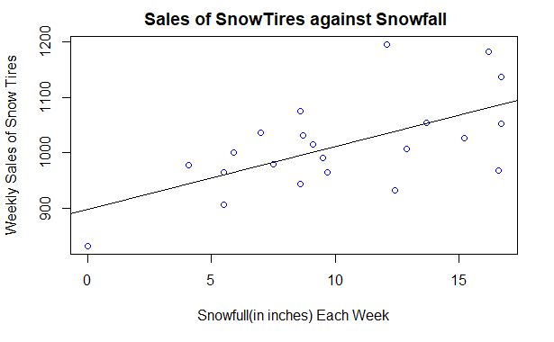

```r
#data processing
data1 <- read.csv("Xr17-57.csv",header = 1)
tires <- data1$Tires
snowfall <- data1$Snowfall
#Scatter diagram
plot(snowfall,tires,col="blue",main = " Sales of SnowTires against Snowfall",xlab="Snowfull(in inches) Each Week",ylab="Weekly Sales of Snow Tires")
abline(lm(tires~snowfall))
```

```r
#
linearModelVar <- lm(tires ~ snowfall)
cat("# # # # The regression model # # # ","\n")
```

```
# # # # The regression model # # #
```

```r
print(summary(linearModelVar))
```

```
Call:
lm(formula = tires ~ snowfall)

Residuals:
     Min       1Q   Median       3Q      Max
-118.031  -43.702   -1.572   35.734  160.938

Coefficients:
            Estimate Std. Error t value Pr(>|t|)
(Intercept)  898.011     35.969  24.967  < 2e-16 ***
snowfall      11.327      3.253   3.482  0.00235 **
---
Signif. codes:  0 ‘***’ 0.001 ‘**’ 0.01 ‘*’ 0.05 ‘.’ 0.1 ‘ ’ 1

Residual standard error: 68.63 on 20 degrees of freedom
Multiple R-squared:  0.3774,    Adjusted R-squared:  0.3462
F-statistic: 12.12 on 1 and 20 DF,  p-value: 0.002353
```

```
Propose a statistical model:
```

$$y\ =\ \beta_0\ +\ \beta_1x\ +\ \varepsilon$$

y = number of snow tires sold weekly

x = amount of snowfall (in inches) in each week

$\varepsilon$ = error variable

```
From the printout, we can get the regression model:
```

$$\hat{y} =\ 898.011 \ +\ 11.327x$$

### b

(1)Multicollinearity

The model does not have a multicollinearity problem, since there is only one independent variable.

(2)Autocorrelation

```r
linearModelVar <- lm(tires ~ snowfall)
cat("# # # # The regression model # # # ","\n")
print(summary(linearModelVar))
ANOVA_T_lm <- anova(linearModelVar)
cat("# # # # The ANOVA Table # # # ","\n")
print(ANOVA_T_lm)
```

[output not shown]

```
2-tail test for first order auto-correlation:
```

$$H_0:\ The\ data\ are\ not\ first-order\ correlated.\\
H_1:\ The\ data\ are\ first-order\ correlated.$$

```r
standarized_errors <- function(y, x) {
   n <- length(y)
   linearModelVar <- lm(y ~ x)
   a <- coef(linearModelVar)[1]
   b <- coef(linearModelVar)[2]
   se <- sigma(linearModelVar)
   x_mean <- mean(x)
   x_var <- var(x)
   h <- vector("double", length = n)
   y_p <- vector("double", length = n)
   Error <- vector("double", length = n)
   Standard_E <- vector("double", length = n)
   for(i in 1:n) {
      h[i] <- (1/n) + (x[i] - x_mean)^2 / (x_var * (n - 1))
      y_p[i] <- a + b * x[i]
      Error[i] <- y[i] - y_p[i]
      Standard_E[i] <- Error[i] / (se * sqrt(1 - h[i]))
      }
    SEh <-cbind(Standard_E,h)
    return(SEh)
}
```

```r
SE <- standarized_errors(tires, snowfall)[ ,1]
Durbin_Watson_Test <- function(x) {
   x_square_sum <- sum(x*x)
   n <- length(x)
   x_d <- vector("double", length = n)
   x_d[1] = 0
   for(j in 2:n) {
      x_d[j] <- x[j] - x[j - 1]
      }
   d <- sum(x_d*x_d) / x_square_sum
    return(d)
}
cat("# # # # The Durbin Watson Test # # # ","\n")
```

```
# # # # The Durbin Watson Test # # #
```

```r
DW_test <- Durbin_Watson_Test(SE)
print(DW_test)
```

```
[1] 1.016998
```

```r
n <- length(tires)
cat("n =  ",n)
```

```
n =   22
```

From the table of Durbin-Watson Statistic(k = 1, n = 22), we find $d_L$ = 1.24 and $d_U$ = 1.43. Since d = 1.016998 < $d_L$ = 1.24, there is sufficient evidence to infer that positive first order auto-correlation exists.

3. Normality

   Hypothesis:

$$H_0:Errors\ are\ normally\ distributed.\\
H_1:Errors\ are\ not\ normally\ distributed.$$

```
Apply the Shapiro-Wilks test of normality.
```

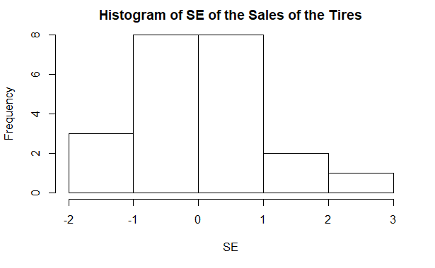

```r
SE <- standarized_errors(tires, snowfall)[ ,1]
hist(SE,main = "Histogram of SE of the Sales of the Tires")
```

```r
cat("# # # # The Normality Test # # # ","\n")
```

```
# # # # The Normality Test # # #
```

```r
norm_test <- shapiro.test(SE)
print(norm_test)
```

```
    Shapiro-Wilk normality test

data:  SE
W = 0.98373, p-value = 0.9639
```

```
Because p_value = 0.9639 > 0.05, do not rejected H0. We can assume that errors are normally distributed.
```

4. Constant Variation

   Hypothesis:

$$H_0:Homoscedasticity\\
H_1:Heteroscedasticity$$

```
Scatter plot:
```

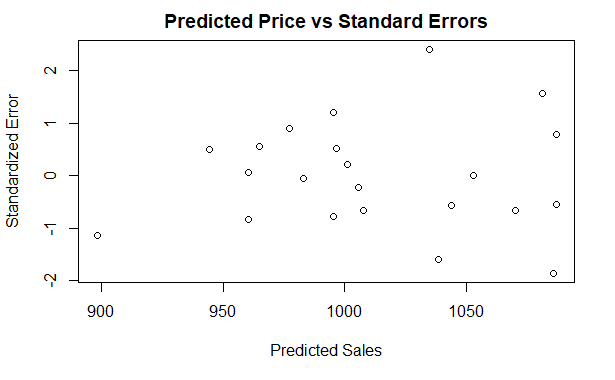

```r
SE <- standarized_errors(tires, snowfall)[ ,1]
n <- length(tires)
linearModelVar <- lm(tires ~ snowfall)
a <- coef(linearModelVar)[1]
b <- coef(linearModelVar)[2]
Price_p <- vector("double", length = n)
for(i in 1:n) {
  Price_p[i] <- a + b * snowfall[i]
}
plot(x = Price_p,y = SE,  xlab = "Predicted Sales",  ylab = "Standardized Error", main = "Predicted Price vs Standard Errors")
```

```
Conclusion:
Do not rejected H0. We can assume that the variation is constant and the mean is around 0.
Heteroscedasticity is NOT a problem.
```

### c

Add a time independent variable(t) to the model.

```r
time <- data1$Time
n <- length(tires)
for(i in 1:n)
{
  time[i] = i-1
}
print(time)
```

```
 [1]  0  1  2  3  4  5  6  7  8  9 10 11 12 13 14 15 16 17 18 19 20 21
```

### d

```r
Data.Tires <- cbind(snowfall,time)
new_linearModelVar <- lm(tires ~ Data.Tires)
cat("# # # # The regression model # # # ","\n")
```

```
# # # # The regression model # # #
```

```r
print(summary(new_linearModelVar))
```

```
Call:
lm(formula = tires ~ Data.Tires)

Residuals:
     Min       1Q   Median       3Q      Max
-107.756  -34.656   -0.325   29.433   75.230

Coefficients:
                   Estimate Std. Error t value Pr(>|t|)
(Intercept)         952.886     28.127  33.878  < 2e-16 ***
Data.Tiressnowfall   13.885      2.368   5.863  1.2e-05 ***
Data.Tirestime       -7.687      1.679  -4.579 0.000205 ***
---
Signif. codes:  0 ‘***’ 0.001 ‘**’ 0.01 ‘*’ 0.05 ‘.’ 0.1 ‘ ’ 1

Residual standard error: 48.55 on 19 degrees of freedom
Multiple R-squared:  0.704, Adjusted R-squared:  0.6728
F-statistic: 22.59 on 2 and 19 DF,  p-value: 9.498e-06
```

From the printout, R-squared = 0.704, which has a significant improvement to the initial one(0.3774). We can infer that 70.4% of the variation in the sale of snow tires is explained by the new model of the 2 independent variables. Only 29.6% remains unexplained by this model.

### e

New model:
$$\hat{y} =b_0\ +\ b_1x\ +\ b_2t\\ =\ 952.886 \ +\ 13.885x -7.687t$$
Use t-test to test the coefficients.

```
Hypothesis for the two coefficients(i = 1,2):
```

$$H_0:\beta_i = 0\\
H_1:\beta_i \neq 0$$

```r
Data.Tires <- cbind(snowfall,time)
new_linearModelVar <- lm(tires ~ Data.Tires)
cat("# # # # The regression model # # # ","\n")
print(summary(new_linearModelVar))
```

[output not shown]

1. for $\beta_1$: Since p-value = 1.2e-05 < 0.05, we reject H0. We conclude that the relationship between the two variables is significant.
2. for $\beta_2$: Since p-value = 0.000205 < 0.05, we reject H0. We conclude that the relationship between the two variables is significant.

## 18.3

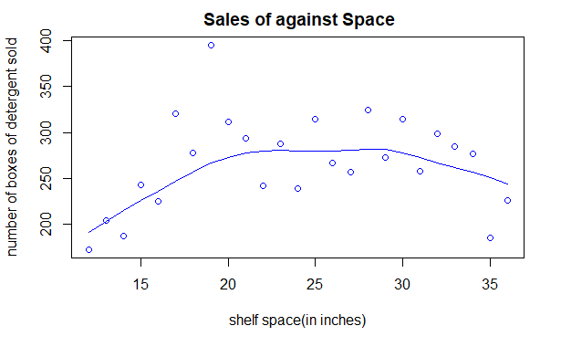

```r
#data processing
data4 <- read.csv("Xr18-03.csv",header = 1)
sales2 <- data4$Sales
space <- data4$Space
#Scatter diagram
plot(space,sales2,col="blue",main = " Sales of against Space",xlab="shelf space(in inches)",ylab="number of boxes of detergent sold")
#abline(lm(sales2~space))
lines(lowess(space, sales2), col="blue")
```

```r
#
linearModelVar <- lm(sales2 ~ space)
cat("# # # # The regression model # # # ","\n")
```

```
# # # # The regression model # # #
```

```r
print(summary(linearModelVar))
```

```
Call:
lm(formula = sales2 ~ space)

Residuals:
    Min      1Q  Median      3Q     Max
-93.782 -28.200  -1.638  30.232 133.519

Coefficients:
            Estimate Std. Error t value Pr(>|t|)
(Intercept)  239.748     35.819   6.693 7.92e-07 ***
space          1.144      1.429   0.800    0.432
---
Signif. codes:  0 ‘***’ 0.001 ‘**’ 0.01 ‘*’ 0.05 ‘.’ 0.1 ‘ ’ 1

Residual standard error: 51.54 on 23 degrees of freedom
Multiple R-squared:  0.02709,   Adjusted R-squared:  -0.01521
F-statistic: 0.6404 on 1 and 23 DF,  p-value: 0.4318
```

R-squared = 0.02709, the model does not fit the data well. From the diagram above, we can infer that there is a quadratic relationship between sales and shelf space.

```
Regression model:
```

$$Sales\ = \beta_0\ +\ \beta_1Space\ +\ \beta_2Space^2\ +\ \varepsilon$$

```r
data4 <- read.csv("Xr18-03.csv",header = 1)
sales2 <- data4$Sales
space <- data4$Space
space_sq <- space^2
Data.Sales2_New <- cbind(space,space_sq)
linearModelVar <- lm(sales2 ~ Data.Sales2_New)
print(summary(linearModelVar))
```

```
Call:
lm(formula = sales2 ~ Data.Sales2_New)

Residuals:
    Min      1Q  Median      3Q     Max
-62.808 -25.063   1.614  26.806 115.550

Coefficients:
                         Estimate Std. Error t value Pr(>|t|)
(Intercept)             -108.9917    97.2405  -1.121 0.274439
Data.Sales2_Newspace      33.0894     8.5897   3.852 0.000864 ***
Data.Sales2_Newspace_sq   -0.6655     0.1774  -3.752 0.001101 **
---
Signif. codes:  0 ‘***’ 0.001 ‘**’ 0.01 ‘*’ 0.05 ‘.’ 0.1 ‘ ’ 1

Residual standard error: 41.15 on 22 degrees of freedom
Multiple R-squared:  0.4068,    Adjusted R-squared:  0.3528
F-statistic: 7.542 on 2 and 22 DF,  p-value: 0.003203
```

From the printout, we can infer that the regression model equation:

$$Sales\ = -108.99\ +\ 33.09Space\ -\ 0.67Space^2\ +\ \varepsilon$$

### b

From the printout above, we have R-squared = 0.4068 We can infer that 40.68% of the variation in the sale of detergent is explained by the model of the quadratic equation. The rest(59.32%) remains unexplained by this model.

## 18.9

### a

```r
#data processing
data5 <- read.csv("Xr18-09.csv",header = 1)
goal <- data5$Goal.diff
faceoff <- data5$Faceoff
penalty <- data5$PM.diff
#scatter diagram
plot(faceoff, goal, col = "blue", main = "Face-off/PM-diff against Goal-diff", xlab = "Face-off or PM-diff", ylab = "Goal-diff", xlim=range(faceoff, penalty))
points(penalty,goal, col= "red")
```

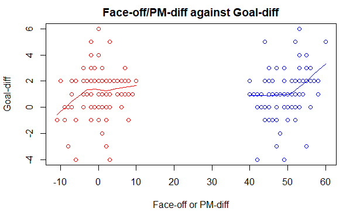

```r
lines(lowess(faceoff, goal), col="blue")
lines(lowess(penalty, goal), col="red")
```

```
First-order model with interaction:
```

$$y\ =\ \beta_0\ +\ \beta_1x_1\ +\ \beta_2x_2\ +\ \beta_3x_1x_2\ +\ \varepsilon$$

y = the diff. between the number of goals their teams scores and those scored by their team’s opponents.

$x_1$ = the percentage of face-offs won

$x_2$ = the penalty-minutes differential

$\varepsilon$ = error variable

```r
faceoff_penalty <- faceoff * penalty
Data.Goal_Inter <- cbind(faceoff,penalty,faceoff_penalty)
linearModelVar <- lm(goal ~ Data.Goal_Inter)
ANOVA_T_lm <- anova(linearModelVar)
cat("# # # # The regression model # # # ","\n")
```

```
# # # # The regression model # # #
```

```r
print(summary(linearModelVar))
```

```
Call:
lm(formula = goal ~ Data.Goal_Inter)

Residuals:
    Min      1Q  Median      3Q     Max
-4.9757 -0.6645  0.0093  0.7985  4.4354

Coefficients:
                                 Estimate Std. Error t value Pr(>|t|)
(Intercept)                    -4.8565893  1.8282415  -2.656  0.00925
Data.Goal_Interfaceoff          0.1211542  0.0366407   3.307  0.00133
Data.Goal_Interpenalty          0.1350127  0.3993079   0.338  0.73601
Data.Goal_Interfaceoff_penalty -0.0009202  0.0079945  -0.115  0.90860

(Intercept)                    **
Data.Goal_Interfaceoff         **
Data.Goal_Interpenalty
Data.Goal_Interfaceoff_penalty
---
Signif. codes:  0 ‘***’ 0.001 ‘**’ 0.01 ‘*’ 0.05 ‘.’ 0.1 ‘ ’ 1

Residual standard error: 1.585 on 96 degrees of freedom
Multiple R-squared:  0.1435,    Adjusted R-squared:  0.1167
F-statistic:  5.36 on 3 and 96 DF,  p-value: 0.001866
```

```
From the printout, we can get the regression model:
```

$$\hat{y} =\ -4.86\ +\ 0.12x_1 \ +\ 0.13x_2\ -\ 0.0009 x_1x_2$$

### b

We use the F-test of ANOVA to test the validity of the model

```
Hypothesis:
```

$$H_0: \beta_1\ =\ \beta_2\ =\ \beta_3\ =\ 0\\
H_1: At\ least\ one\ \beta_i\ is\ not\ equal\ to\ 0.$$

```r
linearModelVar <- lm(goal ~ Data.Goal_Inter)
ANOVA_T_lm <- anova(linearModelVar)
cat("# # # # The ANOVA Table # # # ","\n")
```

```
# # # # The ANOVA Table # # #
```

```r
print(ANOVA_T_lm)
```

```
Analysis of Variance Table

Response: goal
                Df  Sum Sq Mean Sq F value   Pr(>F)
Data.Goal_Inter  3  40.378 13.4593    5.36 0.001866 **
Residuals       96 241.062  2.5111
---
Signif. codes:  0 ‘***’ 0.001 ‘**’ 0.01 ‘*’ 0.05 ‘.’ 0.1 ‘ ’ 1
```

Since p-value = 0.001866 < 0.05, we reject $H_0$. There is sufficient evidence to reject the null hypothesis in favor of the alternative hypothesis. At least one of the $b_i$ is not equal to zero. Thus, at least one independent variable is related to y. This regression model is valid.

### c

Use t-test to test the coefficient og the interaction $b_3$

```
Hypothesis:
```

$$H_0:\ \beta_3\ =\ 0\\
H_1:\ \beta_3\ \neq\ 0$$

```r
linearModelVar <- lm(goal ~ Data.Goal_Inter)
ANOVA_T_lm <- anova(linearModelVar)
cat("# # # # The regression model # # # ","\n")
```

```
# # # # The regression model # # #
```

```r
print(summary(linearModelVar))
```

```
Call:
lm(formula = goal ~ Data.Goal_Inter)

Residuals:
    Min      1Q  Median      3Q     Max
-4.9757 -0.6645  0.0093  0.7985  4.4354

Coefficients:
                                 Estimate Std. Error t value Pr(>|t|)
(Intercept)                    -4.8565893  1.8282415  -2.656  0.00925
Data.Goal_Interfaceoff          0.1211542  0.0366407   3.307  0.00133
Data.Goal_Interpenalty          0.1350127  0.3993079   0.338  0.73601
Data.Goal_Interfaceoff_penalty -0.0009202  0.0079945  -0.115  0.90860

(Intercept)                    **
Data.Goal_Interfaceoff         **
Data.Goal_Interpenalty
Data.Goal_Interfaceoff_penalty
---
Signif. codes:  0 ‘***’ 0.001 ‘**’ 0.01 ‘*’ 0.05 ‘.’ 0.1 ‘ ’ 1

Residual standard error: 1.585 on 96 degrees of freedom
Multiple R-squared:  0.1435,    Adjusted R-squared:  0.1167
F-statistic:  5.36 on 3 and 96 DF,  p-value: 0.001866
```

Maybe it should not be included.